# lab8

LAB 8 Priya Inampudi

```python
import pandas as pd
import numpy as np
from sklearn.model_selection import train_test_split, GridSearchCV, cross_val_score, StratifiedKFold
from sklearn.metrics import confusion_matrix
from sklearn.pipeline import Pipeline
from sklearn.preprocessing import StandardScaler
from sklearn.discriminant_analysis import LinearDiscriminantAnalysis, QuadraticDiscriminantAnalysis
from sklearn.svm import SVC
from sklearn.tree import DecisionTreeClassifier, plot_tree
from sklearn.neighbors import KNeighborsClassifier
from sklearn.linear_model import LogisticRegression
import matplotlib.pyplot as plt
```

**PART 1**

Q1: LDA

```python
df = pd.read_csv("https://www.dropbox.com/s/s2a1uoiegitupjc/cannabis_full.csv?dl=1")
df.head()
```

|  | Strain | Type | Rating | Effects | Flavor | Creative | Energetic | Tingly | Euphoric | Relaxed | ... | Ammonia | Minty | Tree | Fruit | Butter | Pineapple | Tar | Rose | Plum | Pear |
| --- | --- | --- | --- | --- | --- | --- | --- | --- | --- | --- | --- | --- | --- | --- | --- | --- | --- | --- | --- | --- | --- |
| 0 | 100-Og | hybrid | 4.0 | Creative,Energetic,Tingly,Euphoric,Relaxed | Earthy,Sweet,Citrus | 1.0 | 1.0 | 1.0 | 1.0 | 1.0 | ... | 0.0 | 0.0 | 0.0 | 0.0 | 0.0 | 0.0 | 0.0 | 0.0 | 0.0 | 0.0 |
| 1 | 98-White-Widow | hybrid | 4.7 | Relaxed,Aroused,Creative,Happy,Energetic | Flowery,Violet,Diesel | 1.0 | 1.0 | 0.0 | 0.0 | 1.0 | ... | 0.0 | 0.0 | 0.0 | 0.0 | 0.0 | 0.0 | 0.0 | 0.0 | 0.0 | 0.0 |
| 2 | 1024 | sativa | 4.4 | Uplifted,Happy,Relaxed,Energetic,Creative | Spicy/Herbal,Sage,Woody | 1.0 | 1.0 | 0.0 | 0.0 | 1.0 | ... | 0.0 | 0.0 | 0.0 | 0.0 | 0.0 | 0.0 | 0.0 | 0.0 | 0.0 | 0.0 |
| 3 | 13-Dawgs | hybrid | 4.2 | Tingly,Creative,Hungry,Relaxed,Uplifted | Apricot,Citrus,Grapefruit | 1.0 | 0.0 | 1.0 | 0.0 | 1.0 | ... | 0.0 | 0.0 | 0.0 | 0.0 | 0.0 | 0.0 | 0.0 | 0.0 | 0.0 | 0.0 |
| 4 | 24K-Gold | hybrid | 4.6 | Happy,Relaxed,Euphoric,Uplifted,Talkative | Citrus,Earthy,Orange | 0.0 | 0.0 | 0.0 | 1.0 | 1.0 | ... | 0.0 | 0.0 | 0.0 | 0.0 | 0.0 | 0.0 | 0.0 | 0.0 | 0.0 | 0.0 |

5 rows × 69 columns

```python
pd.value_counts(df['Type'])
```

```
Type
hybrid    1212
indica     699
sativa     440
Name: count, dtype: int64
```

```python
df_bin = df[(df["Type"] == "sativa") | (df["Type"] == "indica")].copy()

df_bin["Type_bin"] = (df_bin["Type"] == "sativa").astype(int)

df_bin.drop(columns = ['Strain', 'Effects', 'Flavor'], inplace=True)
```

```python
df_bin.dropna(inplace=True)
df_bin.isnull().sum()
```

```
Type         0
Rating       0
Creative     0
Energetic    0
Tingly       0
            ..
Tar          0
Rose         0
Plum         0
Pear         0
Type_bin     0
Length: 67, dtype: int64
```

```python
X = df_bin.drop(columns=["Type", "Type_bin"])
y = df_bin["Type_bin"]

X_train, X_test, y_train, y_test = train_test_split(
    X, y, test_size=0.25, random_state=42, stratify=y
)
```

```python
lda_pipe = Pipeline([
    ("standardize", StandardScaler()),
    ("lda", LinearDiscriminantAnalysis())
])

lda_cv = cross_val_score(lda_pipe, X_train, y_train, cv=5, scoring="accuracy").mean()
print("LDA CV Accuracy:", lda_cv)

lda_pipe.fit(X_train, y_train)
print("LDA Confusion Matrix:\n", confusion_matrix(y_test, lda_pipe.predict(X_test)))
```

```
LDA CV Accuracy: 0.8353008269175934
LDA Confusion Matrix:
 [[157  15]
 [ 27  81]]
```

Q2: QDA

```python
qda_pipe = Pipeline([
    ("standardize", StandardScaler()),
    ("qda", QuadraticDiscriminantAnalysis())
])

qda_cv = cross_val_score(qda_pipe, X_train, y_train, cv=5, scoring="accuracy").mean()
print("QDA CV Accuracy:", qda_cv)

qda_pipe.fit(X_train, y_train)
print("QDA Confusion Matrix:\n", confusion_matrix(y_test, qda_pipe.predict(X_test)))
```

[output not shown]

```
QDA CV Accuracy: 0.528485885372113
QDA Confusion Matrix:
 [[ 63 109]
 [ 25  83]]
```

Q3: SVC

```python
svc_pipe = Pipeline([
    ("standardize", StandardScaler()),
    ("svc", SVC(kernel="linear"))
])

svc_grid = {"svc__C": [0.01, 0.1, 1, 10, 100]}

svc_search = GridSearchCV(
    svc_pipe, svc_grid, cv=5, scoring="accuracy"
)

svc_search.fit(X_train, y_train)

print("Best SVC param:", svc_search.best_params_)
print("SVC CV Accuracy:", svc_search.best_score_)

svc_best = svc_search.best_estimator_
print("SVC Confusion Matrix:\n", confusion_matrix(y_test, svc_best.predict(X_test)))
```

```
Best SVC param: {'svc__C': 0.01}
SVC CV Accuracy: 0.8352865697177074
SVC Confusion Matrix:
 [[155  17]
 [ 27  81]]
```

Q4: SVM

```python
svm_poly_pipe = Pipeline([
    ("standardize", StandardScaler()),
    ("svm", SVC(kernel="poly", degree=2))
])

svm_poly_grid = {
    "svm__degree": [2, 3, 4],
    "svm__C": [0.1, 1, 10]
}

svm_poly_search = GridSearchCV(
    svm_poly_pipe, svm_poly_grid, cv=5, scoring="accuracy"
)

svm_poly_search.fit(X_train, y_train)

print("Best SVM params:", svm_poly_search.best_params_)
print("SVM CV Accuracy:", svm_poly_search.best_score_)

svm_poly_best = svm_poly_search.best_estimator_
print("SVM Confusion Matrix:\n", confusion_matrix(y_test, svm_poly_best.predict(X_test)))
```

```
Best SVM params: {'svm__C': 10, 'svm__degree': 3}
SVM CV Accuracy: 0.8114627887082978
SVM Confusion Matrix:
 [[153  19]
 [ 32  76]]
```

**PART 2**

Q1: decision tree

```python
df2 = pd.read_csv("https://www.dropbox.com/s/s2a1uoiegitupjc/cannabis_full.csv?dl=1")
df2.head()
pd.value_counts(df2['Type'])
```

```
Type
hybrid    1212
indica     699
sativa     440
Name: count, dtype: int64
```

```python
df2.drop(columns = ['Strain', 'Effects', 'Flavor'], inplace=True)
df2.dropna(inplace=True)
df2.isnull().sum()
```

```
Type         0
Rating       0
Creative     0
Energetic    0
Tingly       0
            ..
Pineapple    0
Tar          0
Rose         0
Plum         0
Pear         0
Length: 66, dtype: int64
```

```python
X2 = df2.drop(columns=["Type"])
y2 = df2["Type"]

X2_train, X2_test, y2_train, y2_test = train_test_split(
    X2, y2, test_size=0.25, random_state=42, stratify=y2
)
```

```python
dt = DecisionTreeClassifier(
    max_depth=4,
    min_samples_leaf=5,
    random_state=42
)
dt.fit(X2_train, y2_train)
print(dt.classes_)
```

```
['hybrid' 'indica' 'sativa']
```

```python
dt_cv_acc = cross_val_score(dt, X2_train, y2_train, cv=5, scoring="accuracy").mean()
print("Decision Tree CV Accuracy:", dt_cv_acc)
```

```
Decision Tree CV Accuracy: 0.6261522995727569
```

```python
print("Decision Tree Confusion Matrix:\n",
      pd.DataFrame(confusion_matrix(y2_test, dt.predict(X2_test)),
                   index=dt.classes_, columns=dt.classes_))
```

```
Decision Tree Confusion Matrix:
         hybrid  indica  sativa
hybrid     192      60      45
indica      53     115       4
sativa      61       6      41
```

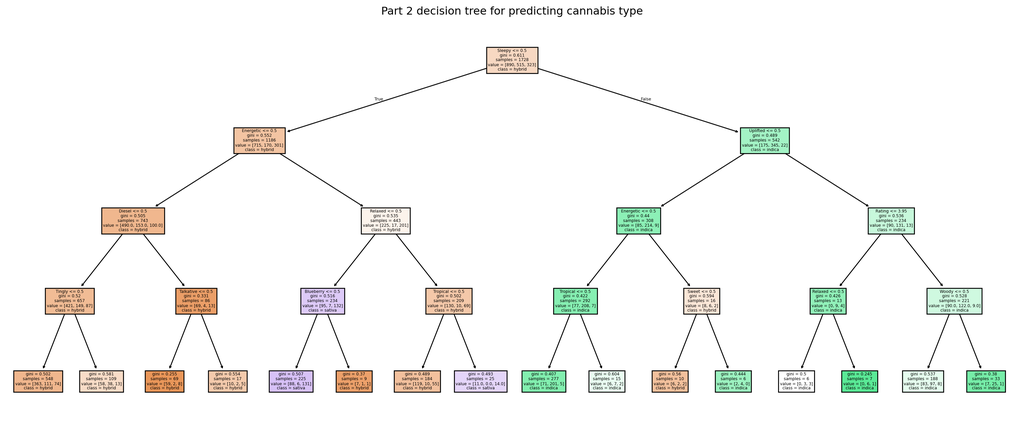

```python
plt.figure(figsize=(20,8))
plot_tree(dt, feature_names=X2.columns, class_names=[str(c) for c in dt.classes_], filled=True)
plt.title("Part 2 decision tree for predicting cannabis type")
plt.show()
```

Q2: repeating analyses

LDA

```python
lda2_pipe = Pipeline([
    ("standardize", StandardScaler()),
    ("lda", LinearDiscriminantAnalysis())
])

lda2_cv = cross_val_score(lda2_pipe, X2_train, y2_train, cv=5, scoring="accuracy").mean()
print("LDA CV Accuracy:", lda2_cv)

lda2_pipe.fit(X2_train, y2_train)
print("LDA Confusion Matrix:\n",
      pd.DataFrame(confusion_matrix(y2_test, lda2_pipe.predict(X2_test)),
                   index=lda2_pipe.named_steps["lda"].classes_,
                   columns=lda2_pipe.named_steps["lda"].classes_))
```

```
LDA CV Accuracy: 0.6284728156153137
LDA Confusion Matrix:
         hybrid  indica  sativa
hybrid     192      54      51
indica      56     110       6
sativa      57       6      45
```

QDA

```python
qda2_pipe = Pipeline([
    ("standardize", StandardScaler()),
    ("qda", QuadraticDiscriminantAnalysis())
])

qda2_cv = cross_val_score(qda2_pipe, X2_train, y2_train, cv=5, scoring="accuracy").mean()
print("QDA CV Accuracy:", qda2_cv)

qda2_pipe.fit(X2_train, y2_train)
print("QDA Confusion Matrix:\n",
      pd.DataFrame(confusion_matrix(y2_test, qda2_pipe.predict(X2_test)),
                   index=qda2_pipe.named_steps["qda"].classes_,
                   columns=qda2_pipe.named_steps["qda"].classes_))
```

```
QDA CV Accuracy: 0.25867973527687027
QDA Confusion Matrix:
         hybrid  indica  sativa
hybrid      28      16     253
indica      13      29     130
sativa      14       5      89
```

[output not shown]

[output cut: 16 more lines]

[output not shown]

KNN - multiclass

```python
knn_pipe = Pipeline([
    ("standardize", StandardScaler()),
    ("knn", KNeighborsClassifier())
])

knn_grid = {
    "knn__n_neighbors": list(range(1, 51)),
    "knn__weights": ["uniform", "distance"]
}

knn_search = GridSearchCV(
    knn_pipe,
    knn_grid,
    scoring="accuracy",
    cv=5,
    n_jobs=-1
)

knn_search.fit(X2_train, y2_train)

print("Best KNN Params:", knn_search.best_params_)
print("KNN CV Accuracy:", knn_search.best_score_)

knn_best = knn_search.best_estimator_
print("KNN Confusion Matrix:\n",
      pd.DataFrame(confusion_matrix(y2_test, knn_best.predict(X2_test)),
                   index=knn_best.classes_,
                   columns=knn_best.classes_))
```

```
Best KNN Params: {'knn__n_neighbors': 39, 'knn__weights': 'distance'}
KNN CV Accuracy: 0.5931858926028315
KNN Confusion Matrix:
         hybrid  indica  sativa
hybrid     251      40       6
indica     102      69       1
sativa      94       3      11
```

Q3:

Overall, the confusion matrices clearly show that the introduction of Hybrid increased class overlap and ambiguity, leading to lower performance across all multiclass classifiers.

**PART 3**

Q1

```python
df3 = pd.read_csv("https://www.dropbox.com/s/s2a1uoiegitupjc/cannabis_full.csv?dl=1")
df3 = df.drop(columns=["Strain", "Effects", "Flavor"], errors="ignore")

df3.dropna(inplace=True)

X3 = df3.drop(columns=["Type"])
y3 = df3["Type"]
```

```python
cv = StratifiedKFold(n_splits=5, shuffle=True, random_state=42)

def run_ovr(model, target_class):
    y3_bin = (y3 == target_class).astype(int)

    X3_train, X3_test, y3_train, y3_test = train_test_split(
        X3, y3_bin, test_size=0.25, random_state=42, stratify=y3_bin
    )

    pipe = Pipeline([
        ("standardize", StandardScaler()),
        ("clf", model)
    ])

    cv_acc = cross_val_score(pipe, X3_train, y3_train, cv=cv, scoring="accuracy").mean()

    pipe.fit(X3_train, y3_train)
    y3_pred = pipe.predict(X3_test)
    cm = confusion_matrix(y3_test, y3_pred)

    return cv_acc, cm, pipe
```

OvR LogReg for all classes

```python
logreg_results = {}

for cls in ["indica", "sativa", "hybrid"]:
    acc, cm, model = run_ovr(
        LogisticRegression(max_iter=2000, solver="liblinear"),
        cls
    )
    logreg_results[cls] = (acc, cm)
    print(f"\nLogistic Regression OvR: {cls} vs Not-{cls}")
    print("cv Accuracy:", acc)
    print("Confusion Matrix:\n", cm)
```

```
Logistic Regression OvR: indica vs Not-indica
cv Accuracy: 0.7945631230627461
Confusion Matrix:
 [[353  52]
 [ 71 101]]

Logistic Regression OvR: sativa vs Not-sativa
cv Accuracy: 0.8229086035017174
Confusion Matrix:
 [[440  29]
 [ 74  34]]

Logistic Regression OvR: hybrid vs Not-hybrid
cv Accuracy: 0.6041484460082097
Confusion Matrix:
 [[163 117]
 [ 84 213]]
```

OvR SVC

```python
svc_results = {}

for cls in ["indica", "sativa", "hybrid"]:
    acc, cm, model = run_ovr(
        SVC(kernel="linear"),
        cls
    )
    svc_results[cls] = (acc, cm)
    print(f"\nSVC OvR: {cls} vs Not-{cls}")
    print("cv Accuracy:", acc)
    print("Confusion Matrix:\n", cm)
```

```
SVC OvR: indica vs Not-indica
cv Accuracy: 0.7847130769875178
Confusion Matrix:
 [[338  67]
 [ 60 112]]

SVC OvR: sativa vs Not-sativa
cv Accuracy: 0.8067035268492921
Confusion Matrix:
 [[466   3]
 [107   1]]

SVC OvR: hybrid vs Not-hybrid
cv Accuracy: 0.613981737454972
Confusion Matrix:
 [[134 146]
 [ 66 231]]
```

The worst-performing models were Hybrid vs Not-Hybrid, with CV accuracies of only 0.604 (LogReg) and 0.614 (SVC). This makessense because Hybrid strains share properties with both Indica and Sativa, so their feature patterns heavily overlap the other two classes.

Indica vs Not-Indica fell in the middle, reflecting the fact that Indica strains are more distinct than Hybrids but less separable than Sativas.

Q3: just 2 groups

```python
cv3 = StratifiedKFold(n_splits=5, shuffle=True, random_state=42)

def run_ovo(model, class1, class2):
    mask = (y3 == class1) | (y3 == class2)
    X3_ovo = X3[mask]
    y3_ovo = y3[mask]

    y3_bin2 = (y3_ovo == class2).astype(int)

    X3_train, X3_test, y3_train, y3_test = train_test_split(
        X3_ovo, y3_bin2, test_size=0.25, random_state=42, stratify=y3_bin2
    )

    pipe2 = Pipeline([
        ("standardize", StandardScaler()),
        ("clf", model)
    ])

    cv3_acc = cross_val_score(pipe2, X3_train, y3_train, cv=cv3, scoring="accuracy").mean()

    pipe2.fit(X3_train, y3_train)
    y3_pred2 = pipe2.predict(X3_test)
    cm2 = confusion_matrix(y3_test, y3_pred2)

    return cv3_acc, cm2
```

```python
logreg_ovo_results = {}

pairs = [
    ("indica", "sativa"),
    ("indica", "hybrid"),
    ("sativa", "hybrid")
]

for c1, c2 in pairs:
    acc, cm = run_ovo(LogisticRegression(max_iter=2000, solver="liblinear"), c1, c2)
    logreg_ovo_results[(c1, c2)] = (acc, cm)

    print(f"\nLogistic Regression OvO: {c1} vs {c2}")
    print("cv Accuracy:", acc)
    print("Confusion Matrix:\n", cm)
```

```
Logistic Regression OvO: indica vs sativa
cv Accuracy: 0.8198317650413459
Confusion Matrix:
 [[155  17]
 [ 31  77]]

Logistic Regression OvO: indica vs hybrid
cv Accuracy: 0.7565836298932384
Confusion Matrix:
 [[106  66]
 [ 47 250]]

Logistic Regression OvO: sativa vs hybrid
cv Accuracy: 0.7733156480631228
Confusion Matrix:
 [[ 36  72]
 [ 49 248]]
```

```python
svc_ovo_results = {}

for c1, c2 in pairs:
    acc, cm = run_ovo(SVC(kernel="linear"), c1, c2)
    svc_ovo_results[(c1, c2)] = (acc, cm)

    print(f"\nSVC OvO: {c1} vs {c2}")
    print("cv Accuracy:", acc)
    print("Confusion Matrix:\n", cm)
```

```
SVC OvO: indica vs sativa
cv Accuracy: 0.8293627031650983
Confusion Matrix:
 [[154  18]
 [ 24  84]]

SVC OvO: indica vs hybrid
cv Accuracy: 0.7523131672597865
Confusion Matrix:
 [[115  57]
 [ 58 239]]

SVC OvO: sativa vs hybrid
cv Accuracy: 0.7609325579022549
Confusion Matrix:
 [[ 34  74]
 [ 37 260]]
```

Q4: The OvO results show that both Logistic Regression and SVC performed best on the indica vs sativa task with accuracies ranging 0.82–0.83. These two pure types are the most distinct in terms of effects and flavors, so separating them is relatively easy.

Performance was intermediate for sativa vs hybrid, which made sense because hybrids retain many of the uplifting descriptors associated with sativas, producing partial overlap.

The worst performance occurred in the indica vs hybrid comparisons, where accuracies dropped to around 0.75 for both models. This makes sense too, since hybrid strains often share sedative and relaxing effects with indica strains, making them more difficult to distinguish in a linear feature space.

Overall, the models performed best when comparing the two pure types, and worst when hybrids, whose properties blend both parent types, were involved.

Q5: By default, LogisticRegression uses the OvR approach when the response variable has more than two classes. This means it fits one binary classifier per class: Class vs. Not-Class. Sklearn only switches to multinomial logistic regression when the user explicitly requests multi_class=“multinomial” and chooses a solver that supports it.

In contrast, SVC uses the OvO approach by default, fitting a separate classifier for every pair of classes and combining predictions by majority vote. This is the standard strategy for kernel SVMs and aligns with sklearn’s default multiclass behavior in the SVM family.